# Practical Machine Learning: Prediction Model Assignment Write-up

Marcelo Rondelli Brito

27 de december de 2015

## Introduction

Using devices such as Jawbone Up, Nike FuelBand, and Fitbit it is now possible to collect a large amount of data about personal activity relatively inexpensively. These type of devices are part of the quantified self movement - a group of enthusiasts who take measurements about themselves regularly to improve their health, to find patterns in their behavior, or because they are tech geeks. One thing that people regularly do is quantify how much of a particular activity they do, but they rarely quantify how well they do it.

In this project, we will use data from accelerometers on the belt, forearm, arm, and dumbell of 6 participants to predict the manner in which they did the exercise.

# Data

The training data for this project are available here: https://d396qusza40orc.cloudfront.net/predmachlearn/pml-training.csv

The test data are available here: https://d396qusza40orc.cloudfront.net/predmachlearn/pml-testing.csv

The data for this project come from this source: http://groupware.les.inf.puc-rio.br/har. If you use the document you create for this class for any purpose please cite them as they have been very generous in allowing their data to be used for this kind of assignment.

## Getting and loading the data

```r
set.seed(12345)
trainUrl <- "http://d396qusza40orc.cloudfront.net/predmachlearn/pml-training.csv"
testUrl <- "http://d396qusza40orc.cloudfront.net/predmachlearn/pml-testing.csv"

trainingRaw <- read.csv(url(trainUrl), na.strings=c("NA","#DIV/0!",""))
testingRaw <- read.csv(url(testUrl), na.strings=c("NA","#DIV/0!",""))
```

## Exploring the Data Set

```r
dim(trainingRaw)
```

```
## [1] 19622   160
```

```r
dim(testingRaw)
```

```
## [1]  20 160
```

We take a quick look at the data and specially at classe…

```r
str(trainingRaw, list.len=20)
```

```
## 'data.frame':    19622 obs. of  160 variables:
##  $ X                       : int  1 2 3 4 5 6 7 8 9 10 ...
##  $ user_name               : Factor w/ 6 levels "adelmo","carlitos",..: 2 2 2 2 2 2 2 2 2 2 ...
##  $ raw_timestamp_part_1    : int  1323084231 1323084231 1323084231 1323084232 1323084232 1323084232 1323084232 1323084232 1323084232 1323084232 ...
##  $ raw_timestamp_part_2    : int  788290 808298 820366 120339 196328 304277 368296 440390 484323 484434 ...
##  $ cvtd_timestamp          : Factor w/ 20 levels "02/12/2011 13:32",..: 9 9 9 9 9 9 9 9 9 9 ...
##  $ new_window              : Factor w/ 2 levels "no","yes": 1 1 1 1 1 1 1 1 1 1 ...
##  $ num_window              : int  11 11 11 12 12 12 12 12 12 12 ...
##  $ roll_belt               : num  1.41 1.41 1.42 1.48 1.48 1.45 1.42 1.42 1.43 1.45 ...
##  $ pitch_belt              : num  8.07 8.07 8.07 8.05 8.07 8.06 8.09 8.13 8.16 8.17 ...
##  $ yaw_belt                : num  -94.4 -94.4 -94.4 -94.4 -94.4 -94.4 -94.4 -94.4 -94.4 -94.4 ...
##  $ total_accel_belt        : int  3 3 3 3 3 3 3 3 3 3 ...
##  $ kurtosis_roll_belt      : num  NA NA NA NA NA NA NA NA NA NA ...
##  $ kurtosis_picth_belt     : num  NA NA NA NA NA NA NA NA NA NA ...
##  $ kurtosis_yaw_belt       : logi  NA NA NA NA NA NA ...
##  $ skewness_roll_belt      : num  NA NA NA NA NA NA NA NA NA NA ...
##  $ skewness_roll_belt.1    : num  NA NA NA NA NA NA NA NA NA NA ...
##  $ skewness_yaw_belt       : logi  NA NA NA NA NA NA ...
##  $ max_roll_belt           : num  NA NA NA NA NA NA NA NA NA NA ...
##  $ max_picth_belt          : int  NA NA NA NA NA NA NA NA NA NA ...
##  $ max_yaw_belt            : num  NA NA NA NA NA NA NA NA NA NA ...
##   [list output truncated]
```

```r
table(trainingRaw$classe)
```

```
##
##    A    B    C    D    E
## 5580 3797 3422 3216 3607
```

```r
prop.table(table(trainingRaw$classe))
```

```
##
##         A         B         C         D         E
## 0.2843747 0.1935073 0.1743961 0.1638977 0.1838243
```

The training data set contains 19622 observations and 160 variables, while the testing data set contains 20 observations and 160 variables. The “classe” variable in the training set is the outcome to predict.

## Cleaning the data

As we could see above, let’s do some basic clean-up removing the six first columns, which there are only for information and reference purposes.

```r
training <- trainingRaw[, 7:160]
testing  <- testingRaw[, 7:160]
```

Now, remove columns that contain NA missing values.

```r
training <- training[, colSums(is.na(training)) == 0]
testing <- testing[, colSums(is.na(testing)) == 0]
```

Finally, remove NearZeroVariance variables if it still exists.

```r
library(caret)
nzv <- nearZeroVar(training, saveMetrics=TRUE)
training <- training[,nzv$nzv==FALSE]

nzv <- nearZeroVar(testing, saveMetrics=TRUE)
testing <- testing[,nzv$nzv==FALSE]
```

## Validate Data Set

```r
inTraining  <- createDataPartition(y=training$classe,p=0.60,list=FALSE)
train1 <- training[inTraining,]
valid1 <- training[-inTraining,]
dim(train1)
```

```
## [1] 11776    54
```

```r
dim(valid1)
```

```
## [1] 7846   54
```

## Data Manipulation

In our data exist a lot of variables, this way, it’s important understand the relative importance for each one covarietes. For this work, we will use the Random Forcast Algorithm and plotting the results using varImpPlot():

```r
library(randomForest)
```

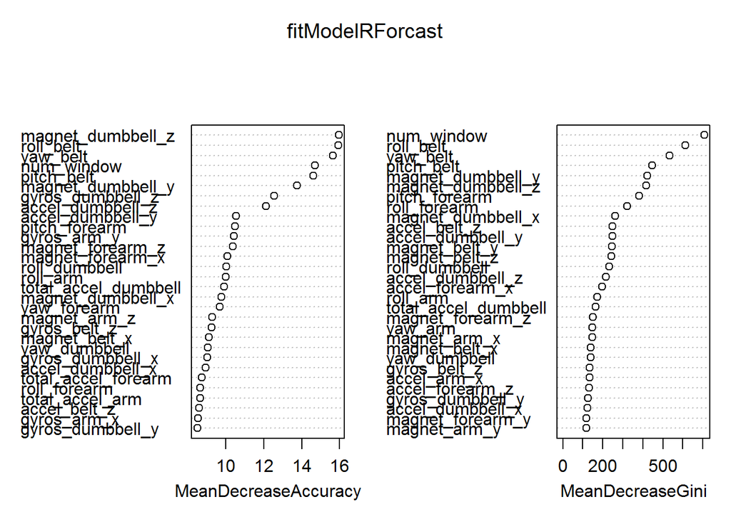

```r
fitModelRForcast <- randomForest(classe~., data=train1, importance=TRUE, ntree=50)
varImpPlot(fitModelRForcast)
```

Using the Accuracy and Gini graphs above, we select the top **13** variables that we’ll use for model building. If the accuracy of the resulting model is acceptable, limiting the number of variables is a good idea to ensure readability and interpretability of the model.

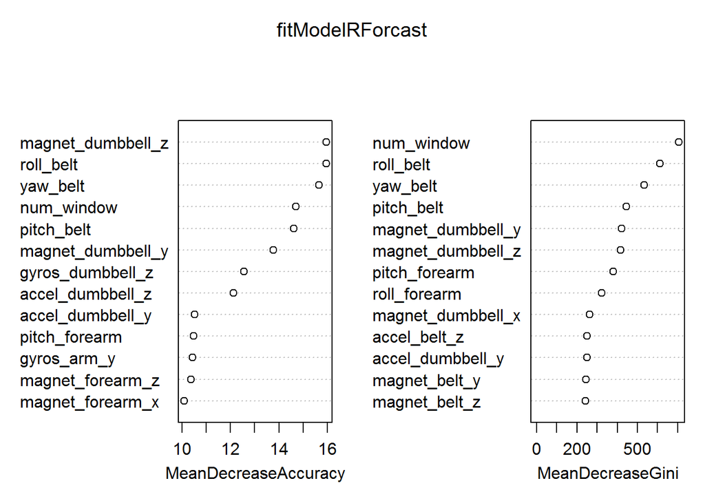

```r
varImpPlot(x=fitModelRForcast,n.var=13)
```

In order to identify and eliminate variables with high correlations among then, the following code calculates the correlation matrix, replaces the 1s in the diagonal with 0s, and outputs which variables have an absolute value correlation above 80%:

```r
correl = cor(train1[,c("magnet_dumbbell_z",
                       "yaw_belt",
                       "roll_belt",
                       "num_window",
                       "pitch_forearm",
                       "gyros_forearm_y",
                       "pitch_belt",
                       "magnet_dumbbell_y",
                       "accel_dumbbell_y",
                       "gyros_arm_y",
                       "gyros_dumbbell_z",
                       "accel_forearm_z",
                       "roll_arm")])
diag(correl) <- 0
which(abs(correl)>0.80, arr.ind=TRUE)
```

```
##           row col
## roll_belt   3   2
## yaw_belt    2   3
```

To select one of them, we performed tree classifier in order to analyse which one has a higher degree of importance.

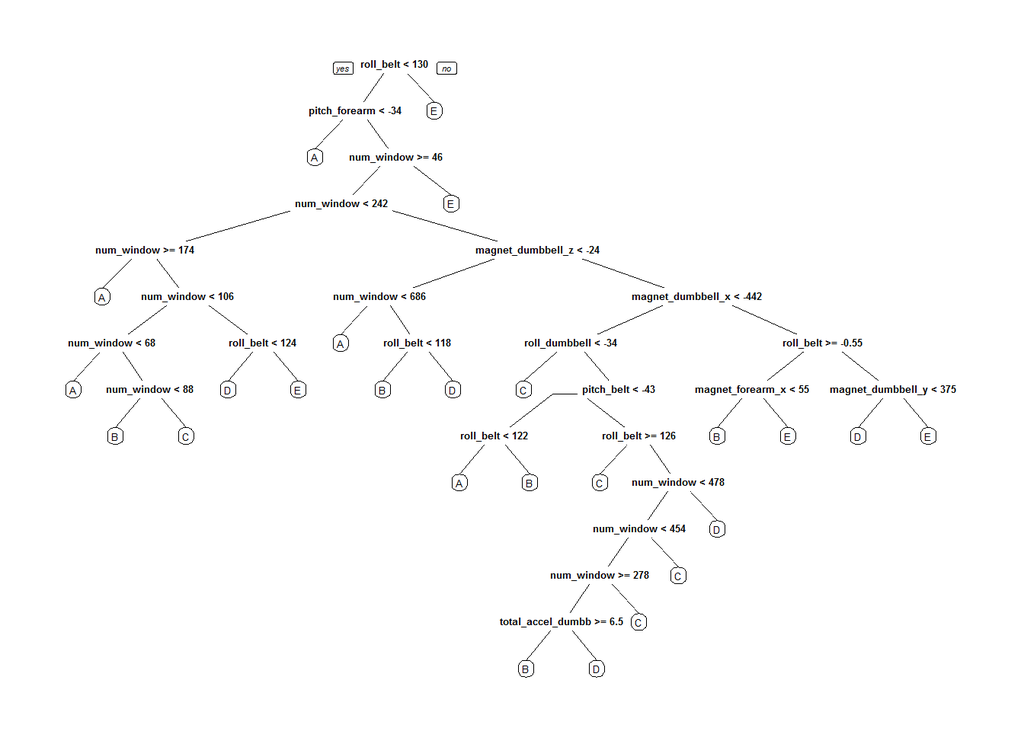

```r
library(rpart)
library(rpart.plot)
fitModelTree <- rpart(classe~., data=train1, method="class")
prp(fitModelTree)
```

In this model, the variable **roll_belt** showed a high degree of relevance, for this reason the *yaw_belt* will be eliminate of our model.

## Prediction Model Set

```r
fitModel <- train(classe~magnet_dumbbell_z+roll_belt+num_window+pitch_forearm+pitch_forearm+gyros_forearm_y+pitch_belt+magnet_dumbbell_y+accel_dumbbell_y+gyros_arm_y+gyros_dumbbell_z+accel_forearm_z+roll_arm,
                  data=train1,
                  method="rf",
                  trControl=trainControl(method="cv",number=2),
                  prox=TRUE,
                  verbose=TRUE,
                  allowParallel=TRUE)
```

Bellow, we examined how accurate is our model on the valid/test data set.

```r
predictions <- predict(fitModel, newdata=valid1)
confusionMat <- confusionMatrix(predictions, valid1$classe)
accuracy <- postResample(predictions, valid1$classe)
accuracy
```

```
##  Accuracy     Kappa
## 0.9974509 0.9967758
```

```r
oose <- 1 - as.numeric(confusionMatrix(valid1$classe, predictions)$overall[1])
oose
```

```
## [1] 0.00254907
```

Great results! The estimated accuracy of the model is **99.75%** and the estimated out-of-sample error is **0.25%**.

## Predicting Results on the Test Data

Now, we apply the model to the original testing data set downloaded from the data source.

```r
result <- predict(fitModel, testing[, -length(names(testing))])
result
```

```
##  [1] B A B A A E D B A A B C B A E E A B B B
## Levels: A B C D E
```

```r
# Write the results to a text file for submission
pml_write_files = function(x){
    n = length(x)
    for(i in 1:n){
        filename = paste0("problem_id_",i,".txt")
        write.table(x[i],file=filename,quote=FALSE,row.names=FALSE,col.names=FALSE)
    }
}

# pml_write_files(result)
```